# Part 3: Overyielding

Created March, 2023

PME

10 March, 2024, 07:26

# Overview

In Part 2, we saw that high-yielding rotations are often, but not always, less reliable. Specifically, the CS rotation was high yielding but also quite susceptible to weather variation. The COWwS rotation was as high-yielding as CS, but was as stable across weather-years as the most stable rotation, CCaWwS, and the lowest-yielding rotation, CSSwS.

What allows COWwS to be so high-yielding? Does corn and soybean yield better in this rotation than in CS?

Steps:

1. Load
2. Assess productivity of corn and soybean within rotation
3. Test yield ~ rotation for cycles 2-4 - to allow legacy effects to accumulate.
4. Contrasts/effects 1. Corn - yield in CS + CCSSw vs other 4-year; CS vs COWwS 2. Soy - yield in CS + CSSwS vs other 4-year; CS vs COWwS 3. And both from diversity, richness, functional group
5. Also test Ww and Sw yield ~ rotation where existing.

## Load

```r
libs = c(
  'here',
  'magrittr',
  'tidyr',
  'lme4',
  'car',
  'ggplot2',
  'gridExtra',
  'emmeans',
  'multcomp',
  'ggtext',
  'wesanderson'
)

for (i in libs) {
  if (!require(i, character.only=TRUE)) {
    renv::install(i)
    library(i, character.only=TRUE)
  }
}
se = function(x) sd(x)/sqrt(length(x))

# selected from color brewer Set1
crop_colors = c(
  Can =  "#4DAF4A",
  Corn = "#FF7F00",
  Oat = "#999999",
  Pea =  "#984EA3",
  Soy =  "#377EB8",
  Swheat = "#F781BF",
  Wwheat = "#E41A1C"
)

rot_colors = c(
  CS     = '#4b4b4b', # dark gray
  CCaWwS = '#B2DF8A', # light green
  CSSwS  = '#33A02C', # green
  COWwS  = '#FB9A99', # light red
  CCSSw  = '#ae1415', # red
  CPWwS  = '#a89ad0', # light purple
  CSSwP  = '#6951b6'  # purple
)

rot_shapes = c(
  CCaWwS = 16,
  CCSwS  = 17,
  COWwS  = 15,
  CPWwS  = 3,
  CS     = 7,
  CSSwP  = 8,
  CSSwS  = 5
)

pseudo_palette_3 = c('#E8601C',
                     '#4EB265',
                     '#1965B0')

pretty_crop = c(
  Can = 'Canola',
  Corn = 'Corn',
  Wwheat = 'Winter\nWheat',
  Swheat = 'Spring\nWheat',
  Oat = 'Oat',
  Pea = 'Pea',
  Soy = 'Soybean'
)
```

```r
in_dir = 'Data'
in_crop = 'crop performance.csv'
in_rot = 'rotation performance.csv'

out_dir = 'Results'

df = here(in_dir, in_crop) %>%
  read.csv

rot = here(in_dir, in_rot) %>%
  read.csv
```

ensure factors are flagged as such

```r
facts =
  c('YEAR',
    'ROTATION',
    'REP',
    'CYCLE',
    'CYCLE_YEAR',
    'PLOT',
    'PREVIOUS',
    'CURRENT',
    'CYCLE_TEXT')

cycle_text = c(
  `1`='2001\n-\n2004',
  `2`='2005\n-\n2008',
  `3`='2009\n-\n2012',
  `4`='2013\n-\n2016'
)

prev_crop_abbrev = c(
  Canola = 'Ca',
  Corn = 'C',
  Oat = 'O',
  Pea = 'P',
  Soy = 'S',
  Swheat = 'Sw',
  Wwheat = 'Ww'
)

df$CYCLE_TEXT = df$CYCLE %>%
  as.character %>%
  cycle_text[.]


is_first_sw = df$YEAR == 2001
df$PREVIOUS[is_first_sw] = NA
df$PREV = df$PREVIOUS %>%
  as.character %>%
  prev_crop_abbrev[.] %>%
  factor(., levels=prev_crop_abbrev)


df[, facts] %<>% lapply(as.factor)
rot[, facts[-c(6:9)]] %<>% lapply(as.factor)




# for plotting
dodge = 0.8
se_hilo = function(x) mean_se(x)[, -c(1)]

# convert yield to Mg/ha
df$YIELD = df$YIELD/1000
rot$YIELD = rot$YIELD/1000
```

# Overall crop yields

```r
crop_plots = list()
alt_plots = list()

mod = lmer(YIELD ~ CURRENT*CYCLE_TEXT + (1|YEAR) + (1|REP:PLOT), data=df)
Anova(mod, test.statistic='F')
```

|  | F | Df | Df.res | Pr(>F) |
| --- | --- | --- | --- | --- |
| CURRENT | 924.765697 | 6 | 1478.839 | 0.000000e+00 |
| CYCLE_TEXT | 1.041117 | 3 | 12.000 | 4.096028e-01 |
| CURRENT:CYCLE_TEXT | 14.923060 | 18 | 1521.289 | 1.534681e-42 |

```r
emmeans(mod, ~CURRENT|CYCLE_TEXT) %>%
  cld(adjust='fdr', Letters=letters, reverse=TRUE)
```

|  | CURRENT | CYCLE_TEXT | emmean | SE | df | lower.CL | upper.CL | .group |
| --- | --- | --- | --- | --- | --- | --- | --- | --- |
| 1 | Corn | 2001\n-\n2004 | 5.2869773 | 0.3335308 | 13.04993 | 4.22471769 | 6.349237 | a |
| 5 | Oat | 2001\n-\n2004 | 4.3141746 | 0.3949992 | 25.60843 | 3.15933111 | 5.469018 | b |
| 4 | Wwheat | 2001\n-\n2004 | 3.6952283 | 0.3490960 | 15.65640 | 2.61588789 | 4.774569 | c |
| 6 | Swheat | 2001\n-\n2004 | 3.2459432 | 0.3490926 | 15.65574 | 2.16660661 | 4.325280 | d |
| 7 | Pea | 2001\n-\n2004 | 2.3995730 | 0.3611049 | 17.91667 | 1.30347155 | 3.495675 | e |
| 3 | Soy | 2001\n-\n2004 | 1.6983543 | 0.3335308 | 13.04993 | 0.63609479 | 2.760614 | f |
| 2 | Can | 2001\n-\n2004 | 1.4680362 | 0.3949992 | 25.60843 | 0.31319273 | 2.622880 | f |
| 8 | Corn | 2005\n-\n2008 | 6.3316497 | 0.3335308 | 13.04993 | 5.26939015 | 7.393909 | a |
| 13 | Pea | 2005\n-\n2008 | 4.0759197 | 0.3611049 | 17.91667 | 2.97981820 | 5.172021 | b |
| 12 | Wwheat | 2005\n-\n2008 | 3.7640458 | 0.3490960 | 15.65640 | 2.68470537 | 4.843386 | bc |

[output cut: 18 more lines]

Main effects

```r
emmm = emmeans(mod, ~CURRENT)
```

```
## NOTE: Results may be misleading due to involvement in interactions
```

```r
cld(emmm, adjust='fdr', Letters=LETTERS, reverse=TRUE, level=.9)
```

|  | CURRENT | emmean | SE | df | lower.CL | upper.CL | .group |
| --- | --- | --- | --- | --- | --- | --- | --- |
| 1 | Corn | 6.019872 | 0.1672973 | 13.21503 | 5.5481665 | 6.491578 | A |
| 5 | Oat | 3.716503 | 0.1997520 | 26.69850 | 3.1929262 | 4.240079 | B |
| 6 | Wwheat | 3.651136 | 0.1754640 | 15.97327 | 3.1688220 | 4.133450 | B |
| 4 | Pea | 3.139988 | 0.1818118 | 18.39127 | 2.6480405 | 3.631935 | C |
| 7 | Swheat | 2.525000 | 0.1754479 | 15.96744 | 2.0427092 | 3.007291 | D |
| 3 | Soy | 2.293513 | 0.1672973 | 13.21502 | 1.8218076 | 2.765219 | E |
| 2 | Can | 1.058951 | 0.1997520 | 26.69850 | 0.5353742 | 1.582527 | F |

Corn easily yielded the most, followed by winter wheat and oats. Soybean was second-worst, well ahead of Canola.

```r
pairs(emmm, adjust='fdr')
```

```
##  contrast        estimate     SE   df t.ratio p.value
##  Can - Corn       -4.9609 0.1231 1402 -40.305  <.0001
##  Can - Oat        -2.6576 0.1653 1287 -16.077  <.0001
##  Can - Pea        -2.0810 0.1432 1271 -14.532  <.0001
##  Can - Soy        -1.2346 0.1231 1402 -10.030  <.0001
##  Can - Swheat     -1.4661 0.1351 1245 -10.853  <.0001
##  Can - Wwheat     -2.5922 0.1321 1594 -19.622  <.0001
##  Corn - Oat        2.3034 0.1231 1402  18.714  <.0001
##  Corn - Pea        2.8799 0.0911 1522  31.609  <.0001
##  Corn - Soy        3.7264 0.0562 1578  66.248  <.0001
##  Corn - Swheat     3.4949 0.0770 1621  45.365  <.0001
##  Corn - Wwheat     2.3687 0.0777 1556  30.487  <.0001
##  Oat - Pea         0.5765 0.1432 1271   4.026  0.0001
##  Oat - Soy         1.4230 0.1231 1402  11.561  <.0001
##  Oat - Swheat      1.1915 0.1351 1245   8.820  <.0001
##  Oat - Wwheat      0.0654 0.1321 1594   0.495  0.6208
##  Pea - Soy         0.8465 0.0911 1522   9.291  <.0001
##  Pea - Swheat      0.6150 0.1049 1560   5.865  <.0001
##  Pea - Wwheat     -0.5111 0.1050 1537  -4.870  <.0001
##  Soy - Swheat     -0.2315 0.0770 1621  -3.005  0.0028
##  Soy - Wwheat     -1.3576 0.0777 1556 -17.474  <.0001
##  Swheat - Wwheat  -1.1261 0.0955 1236 -11.788  <.0001
##
## Results are averaged over the levels of: CYCLE_TEXT
## Degrees-of-freedom method: kenward-roger
## P value adjustment: fdr method for 21 tests
```

```r
within_grp = emmeans(mod, ~CURRENT|CYCLE_TEXT) %>%
  cld(adjust='fdr', Letters=letters, reverse=TRUE)
colnames(within_grp) %<>% gsub('.group', 'WITHIN', .)

across_grp = emmeans(mod, ~CURRENT) %>%
  cld(adjust='fdr', Letters=LETTERS, reverse=TRUE)
```

```
## NOTE: Results may be misleading due to involvement in interactions
```

```r
colnames(across_grp) %<>% gsub('.group', 'ACROSS', .)

grps = merge(within_grp, across_grp[, c('CURRENT', 'ACROSS')], by='CURRENT')
grps[, c('WITHIN', 'ACROSS')] %<>% lapply(trimws)

grps$GROUP = with(grps, paste(WITHIN, ACROSS, sep='\n'))
grps$prettyname = as.character(grps$CURRENT) %>%
  pretty_crop[.] %>%
  paste(' (', grps$ACROSS, ')', sep='')
# grps$CURRENT_GRP = with(grps, paste(CURRENT, ' (', ACROSS, ')', sep=''))

pltdf = merge(df, grps[, c('CURRENT', 'prettyname')], by='CURRENT')
pltdf$CYCLE_TEXT %<>% gsub('\n', ' ', .)

grporder = aggregate(YIELD ~ prettyname + CURRENT, data=pltdf, mean)
curorder = grporder[order(grporder$YIELD, decreasing=TRUE), 'CURRENT']
grporder = grporder[order(grporder$YIELD, decreasing=TRUE), 'prettyname']

pltdf$prettyname %<>% factor(levels=grporder)
```

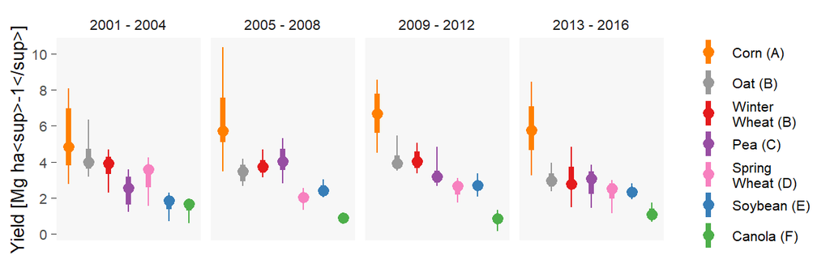

```r
pointranges = function(x, r) {
  r = 1-r
  x %<>% na.omit()
  data.frame(y = median(x),
             ymin = quantile(x, r/2),
             ymax = quantile(x, 1-(r/2)))
}

crop_plots[['all']] =
  ggplot(pltdf,
         aes(x=prettyname,
             y=YIELD,
             color=prettyname)) +
  facet_wrap(~CYCLE_TEXT, nrow=1) +
  scale_color_manual(values=crop_colors[curorder] %>% set_names(NULL)) +
  scale_y_continuous(breaks=seq(0, 14, by=2)) +
  # geom_boxplot(shape=21) +
  stat_summary(fun.data=pointranges,
               geom='pointrange',
               fun.args=list(r=.9),
               size=0.1) +
  stat_summary(fun.data=pointranges,
               geom='pointrange',
               fun.args=list(r=0.5),
               linewidth=1.5,
               size=0.5) +
  labs(x=NULL,
       y='Yield [Mg ha<sup>-1</sup>]',
       color=NULL) +
  theme(panel.grid=element_blank(),
        panel.background=element_rect(fill='#f7f7f7', linewidth=0.1),
        axis.ticks.x=element_blank(),
        axis.ticks.y=element_line(linewidth=0.1),
        axis.text.x=element_blank(),
        strip.background=element_blank(),
        text=element_text(size=10),
        legend.key=element_blank(),
        axis.title=element_markdown())

crop_plots[['all']]
```

Corn yields more than others, canola the least, and oat and winter wheat are tied for second most, though trail corn by maybe 2000 kg/ha.

```r
"Figure 2 - Crop Yields.jpg" %>%
  here(out_dir, .) %>%
  ggsave(crop_plots[['all']], height=2, width=6.5, dpi=300, units='in')
```

# Corn

```r
crop = 'Corn'
subdf = subset(df, CURRENT==crop) %>%
  droplevels

base = subset(subdf, ROTATION=='CS') %>%
  with(., tapply(.$YIELD, .$YEAR, mean))

subdf$BASE = base[subdf$YEAR]
subdf$DIFF = subdf$YIELD - subdf$BASE

mod = lmer(DIFF ~ ROTATION*CYCLE + (1|YEAR) + (1|REP/PLOT), data=subdf)
```

```
## boundary (singular) fit: see help('isSingular')
```

```r
Anova(mod, test.statistic='F')
```

|  | F | Df | Df.res | Pr(>F) |
| --- | --- | --- | --- | --- |
| ROTATION | 32.113703 | 6 | 91.32359 | 1.653349e-20 |
| CYCLE | 1.177490 | 3 | 11.99958 | 3.591827e-01 |
| ROTATION:CYCLE | 3.048476 | 18 | 386.68794 | 3.296412e-05 |

Corn yields differently in different rotations. These differences vary across cycles but not in a substantial way.

## Contrasts

```r
within_grp = emmeans(mod, ~ROTATION|CYCLE) %>%
  cld(adjust='fdr', Letters=letters, reverse=TRUE) %T>%
  print
```

```
## CYCLE = 1:
##  ROTATION  emmean    SE   df lower.CL  upper.CL .group
##  CSSwP     0.9370 0.313 30.9   0.0355  1.838432  a
##  COWwS     0.8505 0.313 30.9  -0.0509  1.751972  a
##  CPWwS     0.6097 0.313 30.9  -0.2918  1.511142  ab
##  CSSwS     0.5090 0.313 30.9  -0.3925  1.410455  ab
##  CCaWwS    0.4709 0.313 30.9  -0.4305  1.372392  ab
##  CS        0.0000 0.313 30.8  -0.9016  0.901606   b
##  CCSSw    -0.7819 0.277 19.1  -1.6159  0.052124    c
##
## CYCLE = 2:
##  ROTATION  emmean    SE   df lower.CL  upper.CL .group
##  CSSwP     1.0406 0.313 30.9   0.1391  1.942017  a
##  CSSwS     0.5475 0.313 30.9  -0.3540  1.448955  ab
##  CS        0.0000 0.313 30.8  -0.9016  0.901606   bc
##  CPWwS    -0.0662 0.313 30.9  -0.9676  0.835267   bcd
##  COWwS    -0.2295 0.313 30.9  -1.1310  0.671955    cd
##  CCaWwS   -0.6749 0.313 30.9  -1.5764  0.226517     de
##  CCSSw    -1.1509 0.277 19.1  -1.9849 -0.316845      e
##
## CYCLE = 3:
##  ROTATION  emmean    SE   df lower.CL  upper.CL .group
##  CSSwS     0.4457 0.313 30.9  -0.4558  1.347142  a
##  COWwS     0.3058 0.313 30.9  -0.5956  1.207267  a
##  CSSwP     0.1646 0.313 30.9  -0.7369  1.066017  a
##  CPWwS     0.1449 0.313 30.9  -0.7565  1.046392  a
##  CS        0.0000 0.313 30.8  -0.9016  0.901606  ab
##  CCaWwS   -0.1651 0.313 30.9  -1.0665  0.736392  ab
##  CCSSw    -0.6017 0.277 19.1  -1.4357  0.232373   b
##
## CYCLE = 4:
##  ROTATION  emmean    SE   df lower.CL  upper.CL .group
##  CSSwP     0.1887 0.313 30.9  -0.7128  1.090142  a
##  CCaWwS    0.0198 0.313 30.9  -0.8817  0.921205  a
##  CS        0.0000 0.313 30.8  -0.9016  0.901606  a
##  CSSwS    -0.1634 0.313 30.9  -1.0648  0.738080  a
##  COWwS    -0.1844 0.313 30.9  -1.0859  0.717017  a
##  CPWwS    -0.9023 0.313 30.9  -1.8038 -0.000858   b
##  CCSSw    -1.0918 0.277 19.1  -1.9258 -0.257752   b
##
## Degrees-of-freedom method: kenward-roger
## Confidence level used: 0.95
## Conf-level adjustment: bonferroni method for 7 estimates
## P value adjustment: fdr method for 21 tests
## significance level used: alpha = 0.05
## NOTE: If two or more means share the same grouping symbol,
##       then we cannot show them to be different.
##       But we also did not show them to be the same.
```

```r
across_grp = emmeans(mod, ~ROTATION) %>%
  cld(Letters=LETTERS, reverse=TRUE, adjust='fdr') %T>%
  print
```

```
## NOTE: Results may be misleading due to involvement in interactions
```

```
##  ROTATION  emmean    SE   df lower.CL upper.CL .group
##  CSSwP     0.5827 0.156 29.6    0.131    1.035  A
##  CSSwS     0.3347 0.156 29.6   -0.117    0.787  AB
##  COWwS     0.1856 0.156 29.6   -0.267    0.638   BC
##  CS        0.0000 0.156 26.9   -0.455    0.455    C
##  CPWwS    -0.0535 0.156 29.6   -0.506    0.399    C
##  CCaWwS   -0.0873 0.156 29.6   -0.539    0.365    C
##  CCSSw    -0.9066 0.138 18.1   -1.326   -0.487     D
##
## Results are averaged over the levels of: CYCLE
## Degrees-of-freedom method: kenward-roger
## Confidence level used: 0.95
## Conf-level adjustment: bonferroni method for 7 estimates
## P value adjustment: fdr method for 21 tests
## significance level used: alpha = 0.05
## NOTE: If two or more means share the same grouping symbol,
##       then we cannot show them to be different.
##       But we also did not show them to be the same.
```

Corn yielded best in CSSwP and worst in CCSwS. Effects were strongest in Cycles 1 and 2.

## Explanations

```r
explmod = lmer(DIFF ~ NSPECIES + PREVIOUS + (1|YEAR) + (1|REP/PLOT),
               data=subset(subdf, YEAR != '2021'))
```

```
## boundary (singular) fit: see help('isSingular')
```

```r
Anova(explmod, test.statistic='F')
```

|  | F | Df | Df.res | Pr(>F) |
| --- | --- | --- | --- | --- |
| NSPECIES | 1.223356 | 1 | 65.13072 | 2.727718e-01 |
| PREVIOUS | 139.532523 | 3 | 130.58462 | 1.491040e-40 |

```r
explmod = lmer(DIFF ~ NSPECIES + (1|YEAR) + (1|REP/PLOT),
               data=subset(subdf, CYCLE != 1))
```

```
## boundary (singular) fit: see help('isSingular')
```

```r
Anova(explmod, test.statistic='F')
```

|  | F | Df | Df.res | Pr(>F) |
| --- | --- | --- | --- | --- |
| NSPECIES | 2.239856 | 1 | 78.03913 | 0.1385271 |

### Diversity

```r
explmod = lmer(DIFF ~ NSPECIES + (1|YEAR) + (1|REP/PLOT),
               data=subset(subdf, CYCLE != 1))
```

```
## boundary (singular) fit: see help('isSingular')
```

```r
Anova(explmod, test.statistic='F')
```

|  | F | Df | Df.res | Pr(>F) |
| --- | --- | --- | --- | --- |
| NSPECIES | 2.239856 | 1 | 78.03913 | 0.1385271 |

### Previous

```r
explmod = lmer(DIFF ~ PREVIOUS + (1|YEAR) + (1|REP/PLOT),
               data=subset(subdf, CYCLE != 1))
```

```
## boundary (singular) fit: see help('isSingular')
```

```r
Anova(explmod, test.statistic='F')
```

|  | F | Df | Df.res | Pr(>F) |
| --- | --- | --- | --- | --- |
| PREVIOUS | 105.0657 | 3 | 135.5235 | 3.385769e-35 |

```r
explgrp = emmeans(explmod, ~PREVIOUS) %>%
  cld(adjust='fdr', Letters=letters, reverse=TRUE) %T>%
  print
```

```
##  PREVIOUS  emmean    SE   df lower.CL upper.CL .group
##  Pea       0.4646 0.164 27.1    0.025    0.904  a
##  Swheat   -0.0377 0.164 27.1   -0.477    0.402   b
##  Soy      -0.0640 0.134 12.3   -0.456    0.328   b
##  Corn     -1.8585 0.164 27.1   -2.298   -1.419    c
##
## Degrees-of-freedom method: kenward-roger
## Confidence level used: 0.95
## Conf-level adjustment: bonferroni method for 4 estimates
## P value adjustment: fdr method for 6 tests
## significance level used: alpha = 0.05
## NOTE: If two or more means share the same grouping symbol,
##       then we cannot show them to be different.
##       But we also did not show them to be the same.
```

But corn still does better after pea.

```r
emmeans(explmod, ~PREVIOUS) %>%
  pairs(adjust='fdr')
```

```
##  contrast      estimate    SE  df t.ratio p.value
##  Corn - Pea     -2.3231 0.151 128 -15.379  <.0001
##  Corn - Soy     -1.7945 0.117 124 -15.283  <.0001
##  Corn - Swheat  -1.8207 0.132 274 -13.830  <.0001
##  Pea - Soy       0.5286 0.117 124   4.501  <.0001
##  Pea - Swheat    0.5024 0.151 128   3.326  0.0014
##  Soy - Swheat   -0.0262 0.117 124  -0.223  0.8238
##
## Degrees-of-freedom method: kenward-roger
## P value adjustment: fdr method for 6 tests
```

```r
summary(explmod)
```

```
## Linear mixed model fit by REML ['lmerMod']
## Formula: DIFF ~ PREVIOUS + (1 | YEAR) + (1 | REP/PLOT)
##    Data: subset(subdf, CYCLE != 1)
##
## REML criterion at convergence: 824.3
##
## Scaled residuals:
##      Min       1Q   Median       3Q      Max
## -2.63899 -0.56385 -0.03433  0.60419  2.78536
##
## Random effects:
##  Groups   Name        Variance Std.Dev.
##  PLOT:REP (Intercept) 0.04389  0.2095
##  YEAR     (Intercept) 0.18701  0.4324
##  REP      (Intercept) 0.00000  0.0000
##  Residual             0.41595  0.6449
## Number of obs: 384, groups:  PLOT:REP, 104; YEAR, 12; REP, 4
##
## Fixed effects:
##                Estimate Std. Error t value
## (Intercept)     -1.8585     0.1643  -11.31
## PREVIOUSPea      2.3231     0.1511   15.38
## PREVIOUSSoy      1.7945     0.1174   15.29
## PREVIOUSSwheat   1.8207     0.1316   13.83
##
## Correlation of Fixed Effects:
##             (Intr) PREVIOUSP PREVIOUSSy
## PREVIOUSPea -0.460
## PREVIOUSSoy -0.591  0.643
## PREVIOUSSwh -0.401  0.436     0.561
## optimizer (nloptwrap) convergence code: 0 (OK)
## boundary (singular) fit: see help('isSingular')
```

But worse in more diverse rotations after accounting for sequencing effects.

## Plot

Based on those results, we will show two graphs: 1. based on previous crop 2. based on rotation.

```r
colnames(within_grp) %<>%
  gsub('.group', 'WITHIN', .)
colnames(across_grp) %<>%
  gsub('.group', 'ACROSS', .)

across_grp$ROTATION_GRP = with(across_grp,
                               paste(ROTATION, ' (',
                                     trimws(ACROSS), ')',
                                     sep=''))

grps = merge(within_grp,
             across_grp[, c('ROTATION', 'ACROSS')],
             by='ROTATION')
grps[, c('ACROSS', 'WITHIN')] %<>%
  lapply(trimws)

grps$ROTATION_GRP = with(grps,
                         paste(ROTATION, ' (', ACROSS, ')',
                               sep=''))

explgrp$PREVIOUS %<>% as.character
explgrp$PREV_GRP = pretty_crop[explgrp$PREVIOUS] %>%
  # prev_crop_abbrev[.] %>%
  paste(' (',
        trimws(explgrp$.group),
        ')', sep='')

pltdf =
  subdf %>%
  merge(grps[, c('ROTATION', 'CYCLE', 'ROTATION_GRP')],
        by=c('ROTATION', 'CYCLE')) %>%
  merge(explgrp[, c('PREVIOUS', 'PREV_GRP')], by='PREVIOUS')
lvls = unique(pltdf$ROTATION_GRP) %>%
  set_names(., strsplit(., ' ') %>% sapply('[', 1)) %>%
  .[names(rot_colors)]
pltdf$ROTATION_GRP %<>% factor(levels=lvls)

prvgrp_order = order(explgrp$emmean, decreasing=TRUE)
pltdf$PREV_GRP %<>% factor(levels=explgrp$PREV_GRP[prvgrp_order])

rotgrp_order = order(across_grp$emmean, decreasing=TRUE)
pltdf$ROTATION_GRP %<>% factor(levels=across_grp$ROTATION_GRP[rotgrp_order])

# shape_order = across_grp %>%
#   as.data.frame %>%
#   set_rownames(.$ROTATION) %>%
#   .[names(lvls), 'emmean'] %>%
#   order(decreasing=TRUE)

shape_order = rot_shapes[across_grp[, 'ROTATION']] %>%
  set_names(NULL)

color_order = crop_colors[explgrp[, 'PREVIOUS']] %>%
  set_names(NULL)
```

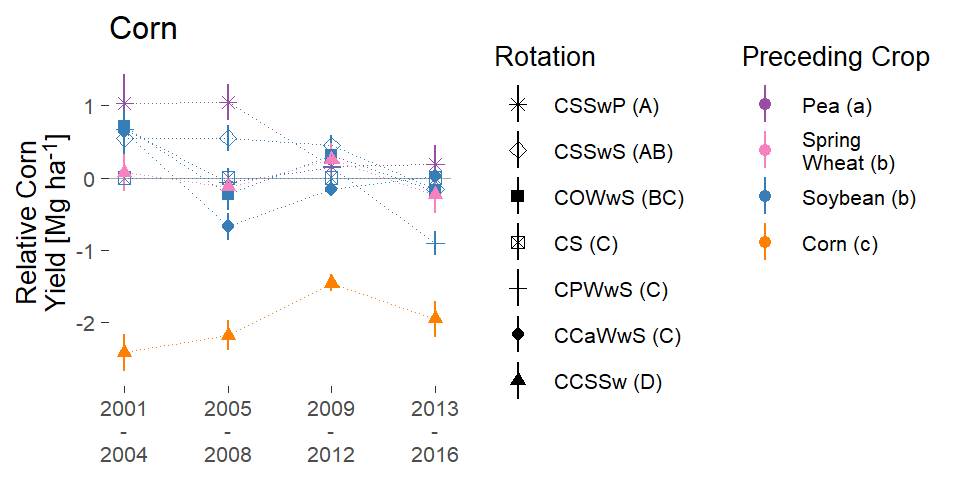

```r
crop_plots[[crop]] =
  ggplot(pltdf,
         aes(x=as.numeric(CYCLE),
             y=DIFF,
             shape=ROTATION_GRP,
             color=PREV_GRP)) +
  scale_x_continuous(breaks=1:4,
                     labels=cycle_text) +
  # scale_color_brewer(palette='Dark2') +
  scale_color_manual(values=color_order) +
  scale_shape_manual(values=shape_order) +
  geom_hline(aes(yintercept=0),
             color='darkgray',
             size=0.3) +
  stat_summary(fun.data=mean_se,
               geom='pointrange',
               stroke=0.2,
               size=0.5) +
  stat_summary(fun=mean,
               geom='path',
               linewidth=0.2,
               linetype=3,
               show.legend=FALSE) +
  labs(title=crop,
       x=NULL,
       y='Relative Corn<br>Yield [Mg ha<sup>-1</sup>]',
       shape='Rotation',
       color='Preceding Crop') +
  guides(color=guide_legend(order=2),
         shape=guide_legend(order=1)) +
  theme(panel.background=element_blank(),
        legend.key=element_blank(),
        strip.background=element_blank(),
        text=element_text(size=10),
        legend.box='horizontal',
        axis.title.y=element_markdown(),
        axis.ticks=element_line(linewidth=0.1))
crop_plots[[crop]]
```

We don’t see consistent evidence of corn overyielding in diverse rotations except possibly in CSSwS and CSSwP. This benefit is immediate and variable, but without an obvious trend.

# Soybean

```r
crop = 'Soy'
subdf = subset(df, CURRENT==crop) %>%
  droplevels

base = subset(subdf, ROTATION=='CS') %>%
  with(., tapply(.$YIELD, .$YEAR, mean))

subdf$BASE = base[subdf$YEAR]
subdf$DIFF = subdf$YIELD - subdf$BASE

mod = lmer(DIFF ~ ROTATION*CYCLE + (1|YEAR) + (1|REP:PLOT), data=subdf)
Anova(mod, test.statistic='F')
```

|  | F | Df | Df.res | Pr(>F) |
| --- | --- | --- | --- | --- |
| ROTATION | 6.203586 | 6 | 92.74209 | 1.671621e-05 |
| CYCLE | 3.452092 | 3 | 11.57099 | 5.291376e-02 |
| ROTATION:CYCLE | 3.384263 | 18 | 377.60955 | 4.875195e-06 |

Corn yields differently in different rotations, which varries across year.

## Contrasts

```r
within_grp = emmeans(mod, ~ROTATION|CYCLE) %>%
  cld(adjust='fdr', Letters=letters, reverse=TRUE) %T>%
  print
```

```
## CYCLE = 1:
##  ROTATION  emmean     SE   df  lower.CL upper.CL .group
##  CSSwP    0.20325 0.0832 39.0 -0.032867    0.439  a
##  CCaWwS   0.17106 0.0832 39.0 -0.065055    0.407  a
##  CPWwS    0.10475 0.0832 39.0 -0.131367    0.341  a
##  CCSSw    0.08382 0.0832 39.0 -0.152301    0.320  a
##  CSSwS    0.07646 0.0748 25.7 -0.142189    0.295  a
##  COWwS    0.00418 0.0832 39.0 -0.231940    0.240  a
##  CS       0.00000 0.0883 47.3 -0.248288    0.248  a
##
## CYCLE = 2:
##  ROTATION  emmean     SE   df  lower.CL upper.CL .group
##  CSSwP    0.23321 0.0832 39.0 -0.002909    0.469  a
##  CPWwS    0.18675 0.0832 39.0 -0.049367    0.423  a
##  COWwS    0.18219 0.0832 39.0 -0.053930    0.418  a
##  CCaWwS   0.09488 0.0832 39.0 -0.141242    0.331  a
##  CSSwS    0.07983 0.0748 25.7 -0.138816    0.298  a
##  CCSSw    0.01819 0.0832 39.0 -0.217930    0.254  a
##  CS       0.00000 0.0883 47.3 -0.248288    0.248  a
##
## CYCLE = 3:
##  ROTATION  emmean     SE   df  lower.CL upper.CL .group
##  CPWwS    0.51506 0.0832 39.0  0.278945    0.751  a
##  COWwS    0.49869 0.0832 39.0  0.262570    0.735  a
##  CCaWwS   0.36600 0.0832 39.0  0.129883    0.602  ab
##  CSSwP    0.34131 0.0832 39.0  0.105195    0.577  ab
##  CSSwS    0.25056 0.0748 25.7  0.031919    0.469   b
##  CCSSw    0.23688 0.0832 39.0  0.000758    0.473   b
##  CS       0.00000 0.0883 47.3 -0.248288    0.248    c
##
## CYCLE = 4:
##  ROTATION  emmean     SE   df  lower.CL upper.CL .group
##  CCaWwS   0.55863 0.0832 39.0  0.322508    0.795  a
##  CSSwP    0.38256 0.0832 39.0  0.146445    0.619  ab
##  CPWwS    0.35700 0.0832 39.0  0.120883    0.593   b
##  CSSwS    0.25178 0.0748 25.7  0.033135    0.470   b
##  COWwS    0.25069 0.0832 39.0  0.014570    0.487   b
##  CCSSw    0.20563 0.0832 39.0 -0.030492    0.442   b
##  CS       0.00000 0.0883 47.3 -0.248288    0.248    c
##
## Degrees-of-freedom method: kenward-roger
## Confidence level used: 0.95
## Conf-level adjustment: bonferroni method for 7 estimates
## P value adjustment: fdr method for 21 tests
## significance level used: alpha = 0.05
## NOTE: If two or more means share the same grouping symbol,
##       then we cannot show them to be different.
##       But we also did not show them to be the same.
```

```r
across_grp = emmeans(mod, ~ROTATION) %>%
  cld(Letters=LETTERS, reverse=TRUE, adjust='fdr') %T>%
  print
```

```
## NOTE: Results may be misleading due to involvement in interactions
```

```
##  ROTATION emmean     SE   df  lower.CL upper.CL .group
##  CCaWwS    0.298 0.0489 59.3  1.61e-01    0.434  A
##  CPWwS     0.291 0.0489 59.3  1.55e-01    0.427  A
##  CSSwP     0.290 0.0489 59.3  1.54e-01    0.426  A
##  COWwS     0.234 0.0489 59.3  9.77e-02    0.370  AB
##  CSSwS     0.165 0.0454 44.0  3.66e-02    0.293   B
##  CCSSw     0.136 0.0489 59.3 -7.43e-05    0.272   BC
##  CS        0.000 0.0572 66.0 -1.59e-01    0.159    C
##
## Results are averaged over the levels of: CYCLE
## Degrees-of-freedom method: kenward-roger
## Confidence level used: 0.95
## Conf-level adjustment: bonferroni method for 7 estimates
## P value adjustment: fdr method for 21 tests
## significance level used: alpha = 0.05
## NOTE: If two or more means share the same grouping symbol,
##       then we cannot show them to be different.
##       But we also did not show them to be the same.
```

Soybean yielded better in all 4-year rotations except CCSSw. This effect grew as the system matured, so that even CCSSw was a better soybean rotation than CS.

## Explanations

```r
explmod = lmer(DIFF ~ NSPECIES + PREVIOUS + (1|YEAR) + (1|REP:PLOT),
               data=subset(subdf, YEAR != 2001))
Anova(explmod, test.statistic='F')
```

|  | F | Df | Df.res | Pr(>F) |
| --- | --- | --- | --- | --- |
| NSPECIES | 22.378902 | 1 | 86.18204 | 8.678508e-06 |
| PREVIOUS | 9.393345 | 2 | 204.37203 | 1.251038e-04 |

```r
summary(explmod)
```

```
## Linear mixed model fit by REML ['lmerMod']
## Formula: DIFF ~ NSPECIES + PREVIOUS + (1 | YEAR) + (1 | REP:PLOT)
##    Data: subset(subdf, YEAR != 2001)
##
## REML criterion at convergence: 30
##
## Scaled residuals:
##      Min       1Q   Median       3Q      Max
## -2.70469 -0.66130  0.02362  0.64675  2.41508
##
## Random effects:
##  Groups   Name        Variance Std.Dev.
##  REP:PLOT (Intercept) 0.01360  0.1166
##  YEAR     (Intercept) 0.02230  0.1493
##  Residual             0.04634  0.2153
## Number of obs: 480, groups:  REP:PLOT, 104; YEAR, 15
##
## Fixed effects:
##                 Estimate Std. Error t value
## (Intercept)    -0.324730   0.107301  -3.026
## NSPECIES        0.149751   0.031643   4.733
## PREVIOUSSwheat  0.155140   0.035871   4.325
## PREVIOUSWwheat -0.002776   0.042548  -0.065
##
## Correlation of Fixed Effects:
##             (Intr) NSPECI PREVIOUSS
## NSPECIES    -0.912
## PREVIOUSSwh -0.091  0.039
## PREVIOUSWwh  0.518 -0.674  0.113
```

### Previous Crop

```r
emmeans(explmod, ~PREVIOUS) %>%
  cld(adjust='fdr', Letters=letters, reverse=TRUE)
```

|  | PREVIOUS | emmean | SE | df | lower.CL | upper.CL | .group |
| --- | --- | --- | --- | --- | --- | --- | --- |
| 3 | Swheat | 0.3358215 | 0.05394576 | 44.50535 | 0.20161259 | 0.4700305 | a |
| 1 | Corn | 0.1806815 | 0.04484897 | 21.89899 | 0.06442446 | 0.2969386 | b |
| 2 | Wwheat | 0.1779057 | 0.04920615 | 30.72340 | 0.05330470 | 0.3025068 | b |

Soybean does best after spring wheat.

```r
emmeans(explmod, ~PREVIOUS) %>%
  pairs(adjust='fdr')
```

```
##  contrast        estimate     SE  df t.ratio p.value
##  Corn - Swheat   -0.15514 0.0360 462  -4.304  0.0001
##  Corn - Wwheat    0.00278 0.0426 110   0.065  0.9481
##  Swheat - Wwheat  0.15792 0.0526 178   3.002  0.0046
##
## Degrees-of-freedom method: kenward-roger
## P value adjustment: fdr method for 3 tests
```

```r
summary(explmod)
```

```
## Linear mixed model fit by REML ['lmerMod']
## Formula: DIFF ~ NSPECIES + PREVIOUS + (1 | YEAR) + (1 | REP:PLOT)
##    Data: subset(subdf, YEAR != 2001)
##
## REML criterion at convergence: 30
##
## Scaled residuals:
##      Min       1Q   Median       3Q      Max
## -2.70469 -0.66130  0.02362  0.64675  2.41508
##
## Random effects:
##  Groups   Name        Variance Std.Dev.
##  REP:PLOT (Intercept) 0.01360  0.1166
##  YEAR     (Intercept) 0.02230  0.1493
##  Residual             0.04634  0.2153
## Number of obs: 480, groups:  REP:PLOT, 104; YEAR, 15
##
## Fixed effects:
##                 Estimate Std. Error t value
## (Intercept)    -0.324730   0.107301  -3.026
## NSPECIES        0.149751   0.031643   4.733
## PREVIOUSSwheat  0.155140   0.035871   4.325
## PREVIOUSWwheat -0.002776   0.042548  -0.065
##
## Correlation of Fixed Effects:
##             (Intr) NSPECI PREVIOUSS
## NSPECIES    -0.912
## PREVIOUSSwh -0.091  0.039
## PREVIOUSWwh  0.518 -0.674  0.113
```

## Plot

Will plot to show the diversity effect.

```r
colnames(within_grp) %<>% gsub('.group', 'WITHIN', .)
colnames(across_grp) %<>% gsub('.group', 'ACROSS', .)

grps = merge(within_grp, across_grp[, c('ROTATION', 'ACROSS')], by='ROTATION')
grps[, c('ACROSS', 'WITHIN')] %<>% lapply(trimws)

grps$ROTATION_GRP = with(grps, paste(ROTATION, ' (', ACROSS, ')', sep=''))

pltdf = subdf %>%
  merge(grps[, c('ROTATION', 'CYCLE', 'WITHIN', 'ROTATION_GRP')],
        by=c('ROTATION', 'CYCLE'))
lvls = unique(pltdf$ROTATION_GRP) %>%
  set_names(., strsplit(., ' ') %>% sapply('[', 1)) %>%
  .[names(rot_colors)]
pltdf$ROTATION_GRP %<>% factor(levels=lvls)


across_grp$ROTATION_GRP =
  with(across_grp,
       paste(ROTATION, ' (',
             trimws(ACROSS),
             ')', sep=''))
rotgrp_order = order(across_grp$emmean, decreasing=TRUE)
pltdf$ROTATION_GRP %<>% factor(levels=across_grp$ROTATION_GRP[rotgrp_order])

shape_order = across_grp %>%
  as.data.frame %>%
  set_rownames(.$ROTATION) %>%
  .[names(lvls), 'emmean'] %>%
  order(decreasing=TRUE)

shape_order = rot_shapes[across_grp[, 'ROTATION']] %>%
  set_names(NULL)
```

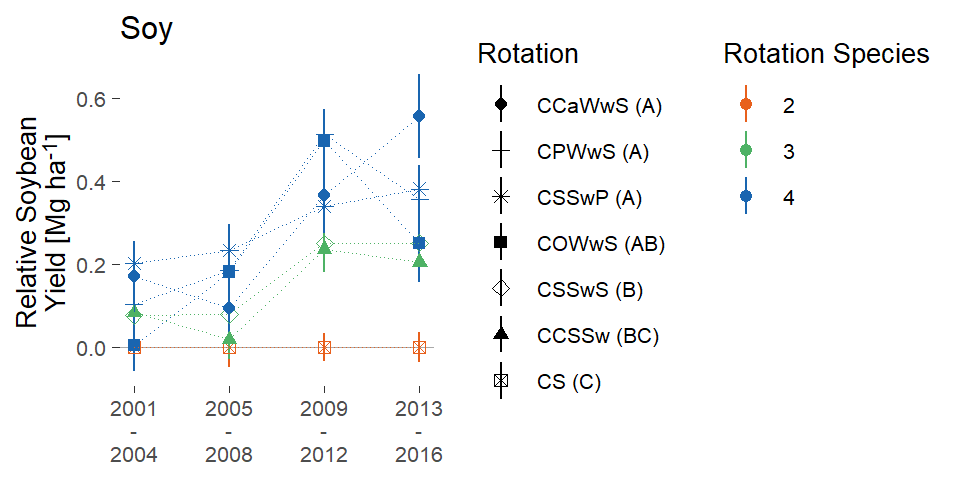

```r
crop_plots[[crop]] =
  ggplot(pltdf,
         aes(x=as.numeric(CYCLE),
             y=DIFF,
             color=factor(NSPECIES),
             shape=ROTATION_GRP)) +
  scale_x_continuous(breaks=1:4,
                     labels=cycle_text) +
  scale_shape_manual(values=shape_order) + #rot_shapes[shape_order]) +
  # scale_color_manual(values=c('#fb580c',
  #                             '#e6c000',
  #                             '#4bac34')) +
  scale_color_manual(values=pseudo_palette_3) +
  geom_hline(aes(yintercept=0),
             color='darkgray',
             size=0.3) +
  stat_summary(fun.data=mean_se,
               geom='pointrange',
               stroke=0.2,
               size=0.5) +
  stat_summary(fun=mean,
               geom='path',
               linewidth=0.2,
               linetype=3,
               show.legend=FALSE) +
  labs(title=crop,
       x=NULL,
       y='Relative Soybean<br>Yield [Mg ha<sup>-1</sup>]',
       color="Rotation Species",
       shape='Rotation') +
  guides(color=guide_legend(order=2),
         shape=guide_legend(order=1)) +
  theme(panel.background=element_blank(),
        legend.key=element_blank(),
        text=element_text(size=10),
        legend.box='horizontal',
        legend.title=element_markdown(hjust=0),
        axis.title.y=element_markdown(),
        axis.ticks=element_line(linewidth=0.1))
crop_plots[[crop]]
```

Clear evidence of overyielding in diverse rotations that develops over time.

# Crop-Level Discussion

We see evidence of overyielding for soybean after spring wheat and in diverse rotations. We don’t see evidence for overyielding in corn, except following pea, and corn does more poorly in diverse rotations.

# Rotation: Overyielding?

What is expected rotation yield? = sum(E(yield|crop)) for all crops in a rotation. I can calculate this within each year-rep.

1. Calculate expected within block based on crop species
2. Calculate observed within block (Fig 1a)
3. Calculate difference

## Calculate expected rotation yield in each rep-year

```r
rotations = list(
  CCaWwS = c('Corn', 'Can', 'Wwheat', 'Soy'),
  CCSSw = c('Corn', 'Corn', 'Soy', 'Swheat'),
  COWwS = c('Corn', 'Oat', 'Wwheat', 'Soy'),
  CPWwS = c('Corn', 'Pea', 'Wwheat', 'Soy'),
  CS = c('Corn', 'Soy'),
  CSSwP = c('Corn', 'Soy', 'Swheat', 'Pea'),
  CSSwS = c('Corn', 'Soy', 'Swheat', 'Soy')
)

get_expected = function(x) {
  crop_yields = tapply(x$YIELD, x$CURRENT, mean)

  sapply(rotations, function(x) {
    mean(crop_yields[x])
  })
}

eyield = split(df, df[, c('YEAR', 'REP')]) %>%
  sapply(get_expected) %>%
  data.frame(ROTATION = rownames(.),
             .) %>%
  pivot_longer(cols=where('is.numeric'),
               values_to='EYIELD',
               names_to='YEAR') %>%
  as.data.frame
eyield[, c('YEAR', 'REP')] = strsplit(eyield$YEAR, '\\.') %>%
  do.call(rbind, .)
eyield$YEAR %<>% gsub('X', '', .)
```

## Combine with observed rotation yield

```r
mergers = c('ROTATION', 'YEAR', 'REP')
for (i in mergers) {
  eyield[, i] %<>% factor(levels=levels(rot[, i]))
}

eyield %<>% merge(rot[, c(mergers, 'CYCLE', 'CYCLE_YEAR', 'YIELD')],
                  by=mergers,
                  all.x=TRUE)
eyield$CYCLE_TEXT = eyield$CYCLE %>%
  as.character %>%
  cycle_text[.]
eyield$DIFF = with(eyield, YIELD - EYIELD)
```

## Test

```r
mod = na.omit(eyield) %>%
  lmer(DIFF ~ ROTATION*CYCLE + (1|YEAR) + (1|REP/CYCLE_YEAR),
       data=.)
```

```
## boundary (singular) fit: see help('isSingular')
```

```r
Anova(mod, test.statistic='F')
```

|  | F | Df | Df.res | Pr(>F) |
| --- | --- | --- | --- | --- |
| ROTATION | 56.6987052 | 6 | 397.80000 | 1.790656e-50 |
| CYCLE | 0.1704103 | 3 | 11.23729 | 9.141839e-01 |
| ROTATION:CYCLE | 5.4008277 | 18 | 397.80000 | 2.485279e-11 |

```r
within_grp = emmeans(mod, ~ROTATION|CYCLE) %>%
  cld(adjust='fdr', Letters=letters, reverse=TRUE) %T>%
  print
```

```
## CYCLE = 1:
##  ROTATION  emmean     SE  df lower.CL upper.CL .group
##  CSSwP     0.2141 0.0536 247  0.06869   0.3594  a
##  COWwS     0.1430 0.0536 247 -0.00232   0.2884  a
##  CPWwS     0.1026 0.0536 247 -0.04274   0.2480  a
##  CCaWwS    0.0608 0.0536 247 -0.08458   0.2062  a
##  CSSwS     0.0531 0.0536 247 -0.09227   0.1985  a
##  CS       -0.1583 0.0536 247 -0.30370  -0.0130   b
##  CCSSw    -0.4945 0.0536 247 -0.63985  -0.3491    c
##
## CYCLE = 2:
##  ROTATION  emmean     SE  df lower.CL upper.CL .group
##  CSSwP     0.4158 0.0536 247  0.27047   0.5612  a
##  CSSwS     0.1857 0.0536 247  0.04032   0.3311   b
##  CS        0.0506 0.0536 247 -0.09478   0.1960   bc
##  COWwS     0.0443 0.0536 247 -0.10105   0.1897   bc
##  CCaWwS   -0.0816 0.0536 247 -0.22693   0.0638    cd
##  CPWwS    -0.1173 0.0536 247 -0.26264   0.0281     d
##  CCSSw    -0.4723 0.0536 247 -0.61769  -0.3269      e
##
## CYCLE = 3:
##  ROTATION  emmean     SE  df lower.CL upper.CL .group
##  CSSwP     0.1277 0.0536 247 -0.01771   0.2730  a
##  COWwS     0.1196 0.0536 247 -0.02581   0.2649  a
##  CSSwS     0.0840 0.0536 247 -0.06142   0.2293  ab
##  CCaWwS    0.0639 0.0536 247 -0.08148   0.2093  ab
##  CPWwS    -0.0520 0.0536 247 -0.19733   0.0934   bc
##  CS       -0.1345 0.0536 247 -0.27985   0.0109    cd
##  CCSSw    -0.2759 0.0536 247 -0.42125  -0.1305     d
##
## CYCLE = 4:
##  ROTATION  emmean     SE  df lower.CL upper.CL .group
##  CCaWwS    0.2967 0.0536 247  0.15133   0.4421  a
##  CSSwP     0.2377 0.0536 247  0.09236   0.3831  a
##  CS        0.0604 0.0536 247 -0.08492   0.2058   b
##  CSSwS     0.0172 0.0536 247 -0.12817   0.1626   b
##  COWwS    -0.0245 0.0536 247 -0.16990   0.1208   b
##  CPWwS    -0.2216 0.0536 247 -0.36695  -0.0762    c
##  CCSSw    -0.3357 0.0536 247 -0.48112  -0.1904    c
##
## Degrees-of-freedom method: kenward-roger
## Confidence level used: 0.95
## Conf-level adjustment: bonferroni method for 7 estimates
## P value adjustment: fdr method for 21 tests
## significance level used: alpha = 0.05
## NOTE: If two or more means share the same grouping symbol,
##       then we cannot show them to be different.
##       But we also did not show them to be the same.
```

```r
across_grp = emmeans(mod, ~ROTATION) %>%
  cld(Letters=LETTERS, reverse=TRUE, adjust='fdr') %T>%
  print
```

```
## NOTE: Results may be misleading due to involvement in interactions
```

```
##  ROTATION  emmean     SE  df lower.CL upper.CL .group
##  CSSwP     0.2488 0.0268 100  0.17523  0.32242  A
##  CSSwS     0.0850 0.0268 100  0.01139  0.15858   B
##  CCaWwS    0.0850 0.0268 100  0.01137  0.15855   B
##  COWwS     0.0706 0.0268 100 -0.00299  0.14419   B
##  CS       -0.0454 0.0268 100 -0.11904  0.02815    C
##  CPWwS    -0.0720 0.0268 100 -0.14564  0.00155    C
##  CCSSw    -0.3946 0.0268 100 -0.46820 -0.32101     D
##
## Results are averaged over the levels of: CYCLE
## Degrees-of-freedom method: kenward-roger
## Confidence level used: 0.95
## Conf-level adjustment: bonferroni method for 7 estimates
## P value adjustment: fdr method for 21 tests
## significance level used: alpha = 0.05
## NOTE: If two or more means share the same grouping symbol,
##       then we cannot show them to be different.
##       But we also did not show them to be the same.
```

CSSwP showed overyielding, probalby due to the pea-corn benefits. We see weak overyielding in COWwS, CSSwS, and CCaWwS. We see underyielding in CS, CPWwS, and especially CCSSw. Where CCaWwS was successful it generaly was neutral. Effects emerged immediately, suggesting they’re corn-driven.

```r
aggregate(DIFF ~ ROTATION, data=na.omit(eyield), mean)
```

| ROTATION | DIFF |
| --- | --- |
| CCaWwS | 0.08495809 |
| CCSSw | -0.39460346 |
| COWwS | 0.07059911 |
| CPWwS | -0.07204287 |
| CS | -0.04544278 |
| CSSwP | 0.24882436 |
| CSSwS | 0.08498616 |

```r
aggregate(DIFF ~ ROTATION, data=na.omit(eyield), function(x) sd(x)/sqrt(length(x)))
```

| ROTATION | DIFF |
| --- | --- |
| CCaWwS | 0.02675661 |
| CCSSw | 0.03094984 |
| COWwS | 0.02450425 |
| CPWwS | 0.02413798 |
| CS | 0.04162307 |
| CSSwP | 0.02846841 |
| CSSwS | 0.02235977 |

```r
aggregate(DIFF ~ ROTATION, data=na.omit(eyield), function(x) t.test(x)$p.value)
```

| ROTATION | DIFF |
| --- | --- |
| CCaWwS | 2.317723e-03 |
| CCSSw | 4.176246e-19 |
| COWwS | 5.411210e-03 |
| CPWwS | 4.037680e-03 |
| CS | 2.790923e-01 |
| CSSwP | 1.825266e-12 |
| CSSwS | 3.276253e-04 |

```r
summary(mod)
```

```
## Linear mixed model fit by REML ['lmerMod']
## Formula: DIFF ~ ROTATION * CYCLE + (1 | YEAR) + (1 | REP/CYCLE_YEAR)
##    Data: .
##
## REML criterion at convergence: -24.2
##
## Scaled residuals:
##     Min      1Q  Median      3Q     Max
## -2.7022 -0.6153 -0.0585  0.6439  3.9131
##
## Random effects:
##  Groups         Name        Variance  Std.Dev.
##  YEAR           (Intercept) 0.000e+00 0.000e+00
##  CYCLE_YEAR:REP (Intercept) 3.086e-21 5.555e-11
##  REP            (Intercept) 2.888e-17 5.374e-09
##  Residual                   4.595e-02 2.144e-01
## Number of obs: 448, groups:  YEAR, 16; CYCLE_YEAR:REP, 16; REP, 4
##
## Fixed effects:
##                       Estimate Std. Error t value
## (Intercept)           0.060796   0.053588   1.135
## ROTATIONCCSSw        -0.555271   0.075785  -7.327
## ROTATIONCOWwS         0.082252   0.075785   1.085
## ROTATIONCPWwS         0.041835   0.075785   0.552
## ROTATIONCS           -0.219126   0.075785  -2.891
## ROTATIONCSSwP         0.153262   0.075785   2.022
## ROTATIONCSSwS        -0.007690   0.075785  -0.101
## CYCLE2               -0.142354   0.075785  -1.878
## CYCLE3                0.003094   0.075785   0.041
## CYCLE4                0.235908   0.075785   3.113
## ROTATIONCCSSw:CYCLE2  0.164514   0.107176   1.535
## ROTATIONCOWwS:CYCLE2  0.043623   0.107176   0.407
## ROTATIONCPWwS:CYCLE2 -0.077550   0.107176  -0.724
## ROTATIONCS:CYCLE2     0.351274   0.107176   3.278
## ROTATIONCSSwP:CYCLE2  0.344138   0.107176   3.211
## ROTATIONCSSwS:CYCLE2  0.274936   0.107176   2.565
## ROTATIONCCSSw:CYCLE3  0.215504   0.107176   2.011
## ROTATIONCOWwS:CYCLE3 -0.026580   0.107176  -0.248
## ROTATIONCPWwS:CYCLE3 -0.157679   0.107176  -1.471
## ROTATIONCS:CYCLE3     0.020755   0.107176   0.194
## ROTATIONCSSwP:CYCLE3 -0.089486   0.107176  -0.835
## ROTATIONCSSwS:CYCLE3  0.027754   0.107176   0.259
## ROTATIONCCSSw:CYCLE4 -0.077179   0.107176  -0.720
## ROTATIONCOWwS:CYCLE4 -0.403486   0.107176  -3.765
## ROTATIONCPWwS:CYCLE4 -0.560117   0.107176  -5.226
## ROTATIONCS:CYCLE4    -0.017128   0.107176  -0.160
## ROTATIONCSSwP:CYCLE4 -0.212236   0.107176  -1.980
## ROTATIONCSSwS:CYCLE4 -0.271817   0.107176  -2.536
```

```
##
## Correlation matrix not shown by default, as p = 28 > 12.
## Use print(x, correlation=TRUE)  or
##     vcov(x)        if you need it
```

```
## optimizer (nloptwrap) convergence code: 0 (OK)
## boundary (singular) fit: see help('isSingular')
```

## Explanations

```r
subdf = eyield %>% #subset(eyield, CYCLE != 1) %>%
  merge(unique(df[, c('ROTATION', 'NSPECIES')]), by='ROTATION')

explmod = lmer(DIFF ~ NSPECIES*CYCLE  + (1|YEAR) + (1|REP:CYCLE_YEAR),
               data=subdf)
```

```
## boundary (singular) fit: see help('isSingular')
```

```r
Anova(explmod, test.statistic='F')
```

|  | F | Df | Df.res | Pr(>F) |
| --- | --- | --- | --- | --- |
| NSPECIES | 31.567229 | 1 | 417.89474 | 3.523227e-08 |
| CYCLE | 0.095521 | 3 | 11.38623 | 9.609692e-01 |
| NSPECIES:CYCLE | 3.013221 | 3 | 417.89474 | 2.990942e-02 |

```r
summary(explmod)
```

```
## Linear mixed model fit by REML ['lmerMod']
## Formula: DIFF ~ NSPECIES * CYCLE + (1 | YEAR) + (1 | REP:CYCLE_YEAR)
##    Data: subdf
##
## REML criterion at convergence: 183.3
##
## Scaled residuals:
##     Min      1Q  Median      3Q     Max
## -2.6962 -0.5692 -0.0280  0.6040  3.3623
##
## Random effects:
##  Groups         Name        Variance Std.Dev.
##  YEAR           (Intercept) 0.00000  0.0000
##  REP:CYCLE_YEAR (Intercept) 0.00000  0.0000
##  Residual                   0.08197  0.2863
## Number of obs: 448, groups:  YEAR, 16; REP:CYCLE_YEAR, 16
##
## Fixed effects:
##                 Estimate Std. Error t value
## (Intercept)     -0.66927    0.13018  -5.141
## NSPECIES         0.19191    0.03714   5.167
## CYCLE2           0.48836    0.18410   2.653
## CYCLE3           0.26970    0.18410   1.465
## CYCLE4           0.47520    0.18410   2.581
## NSPECIES:CYCLE2 -0.13809    0.05252  -2.629
## NSPECIES:CYCLE3 -0.07817    0.05252  -1.488
## NSPECIES:CYCLE4 -0.13404    0.05252  -2.552
##
## Correlation of Fixed Effects:
##                 (Intr) NSPECIES CYCLE2 CYCLE3 CYCLE4 NSPECIES:CYCLE2
## NSPECIES        -0.978
## CYCLE2          -0.707  0.692
## CYCLE3          -0.707  0.692    0.500
## CYCLE4          -0.707  0.692    0.500  0.500
## NSPECIES:CYCLE2  0.692 -0.707   -0.978 -0.489 -0.489
## NSPECIES:CYCLE3  0.692 -0.707   -0.489 -0.978 -0.489  0.500
## NSPECIES:CYCLE4  0.692 -0.707   -0.489 -0.489 -0.978  0.500
##                 NSPECIES:CYCLE3
## NSPECIES
## CYCLE2
## CYCLE3
## CYCLE4
## NSPECIES:CYCLE2
## NSPECIES:CYCLE3
## NSPECIES:CYCLE4  0.500
## optimizer (nloptwrap) convergence code: 0 (OK)
## boundary (singular) fit: see help('isSingular')
```

## Plot

```r
colnames(within_grp) %<>% gsub('.group', 'WITHIN', .)
colnames(across_grp) %<>% gsub('.group', 'ACROSS', .)

grps = merge(within_grp, across_grp[, c('ROTATION', 'ACROSS')], by='ROTATION')
grps[, c('ACROSS', 'WITHIN')] %<>% lapply(trimws)

grps$GROUP = with(grps, paste(WITHIN, ACROSS, sep='\n'))
grps$ROTATION_GRP = with(grps, paste(ROTATION, ' (', ACROSS, ')', sep=''))

pltdf = subdf %>%
  merge(grps[, c('ROTATION', 'ROTATION_GRP')], by='ROTATION')

lvls = unique(pltdf$ROTATION_GRP) %>%
  set_names(., strsplit(., ' ') %>% sapply('[', 1)) %>%
  .[names(rot_colors)]

pltdf$ROTATION_GRP %<>% factor(levels=lvls)

across_grp$ROTATION_GRP =
  with(across_grp,
       paste(ROTATION, ' (',
             trimws(ACROSS),
             ')', sep=''))
rotgrp_order = order(across_grp$emmean, decreasing=TRUE)
pltdf$ROTATION_GRP %<>% factor(levels=across_grp$ROTATION_GRP[rotgrp_order])

shape_order = across_grp %>%
  as.data.frame %>%
  set_rownames(.$ROTATION) %>%
  .[names(lvls), 'emmean'] %>%
  order(decreasing=TRUE)
```

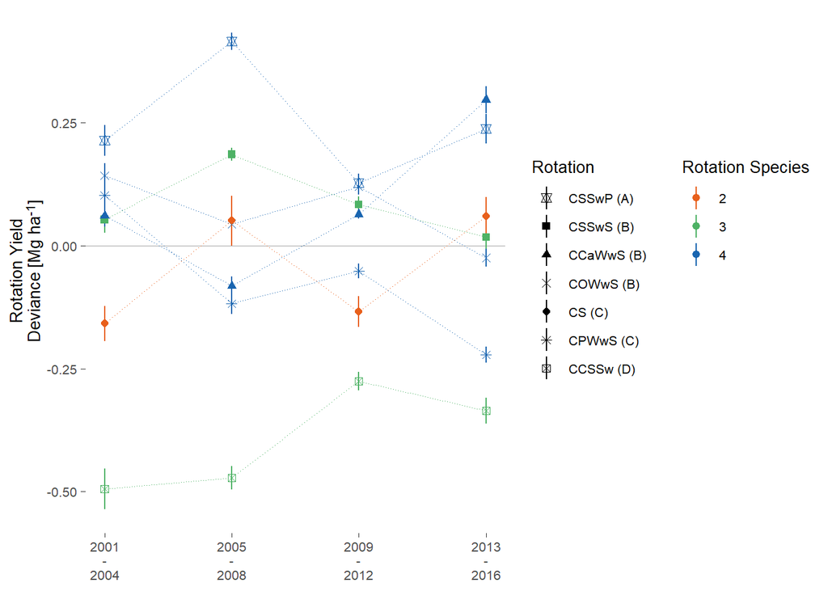

```r
crop_plots[['overyield']] =
  ggplot(pltdf,
         aes(x=as.numeric(CYCLE),
             y=DIFF,
             shape=ROTATION_GRP,
             color=as.factor(NSPECIES))) +
  scale_x_continuous(breaks=1:4,
                     labels=cycle_text) +
  # scale_color_manual(values=c('#fb580c',
  #                             '#e6c000',
  #                             '#4bac34')) +
  scale_color_manual(values=pseudo_palette_3) +
  scale_shape_manual(values=c(16, 17, 15, 4, 7, 8, 11)[shape_order]) +
  geom_hline(aes(yintercept=0),
             color='darkgray',
             size=0.3) +
  stat_summary(fun.data=mean_se,
               geom='pointrange',
               stroke=0.2,
               size=0.5) +
  stat_summary(fun=mean,
               geom='path',
               linewidth=0.3,
               linetype=3,
               show.legend=FALSE) +
  labs(x=NULL,
       y='Rotation Yield<br>Deviance [Mg ha<sup>-1</sup>]',
       shape='Rotation',
       color="Rotation Species") +
  guides(shape=guide_legend(order=1),
         color=guide_legend(order=2)) +
  theme(panel.background=element_blank(),
        legend.key=element_blank(),
        strip.background=element_blank(),
        text=element_text(size=10),
        legend.title=element_markdown(hjust=0),
        legend.box='horizontal',
        axis.ticks=element_line(linewidth=0.1),
        axis.title.y=element_markdown())#(orientation='left-rotated'))
crop_plots[['overyield']]
```

CS underyields relative to more diverse rotations. CCSSw definitely underyields.

# Export

```r
# colors from https://davidmathlogic.com/colorblind/

p1 = crop_plots$all +
  labs(tag='a)') +
  # guides(fill=guide_legend(label.position='bottom',
                           # nrow=1)) +
  theme(text=element_text(size=8),
        strip.text=element_blank(),
        # legend.margin=margin(b=10),
        legend.key.height=unit(0.18, 'in'))

p2 = crop_plots$Corn +
  labs(tag='a)',
       title=NULL) +
  # scale_color_manual(values=c('#EE6677', '#228833', '#CCBB44', '#4477AA')) +
  guides(color=guide_legend(ncol=2, order=1),
         shape=guide_legend(ncol=2,
                            order=2,
                            # override.aes=list(color='#555555')
                            )) +
  theme(text=element_text(size=8),
        axis.text.x=element_blank(),
        # axis.ticks.x=element_blank(),
        legend.key.height=unit(0.12, 'in'),
        legend.box='vertical',
        legend.margin=margin(t=-0.25, unit='cm'))

p3 = crop_plots$Soy +
  labs(tag='b)',
       title=NULL) +
  # scale_color_manual(values=c('#E8601C',
  #                             '#4EB265',
  #                             '#1965B0')) +
  guides(color=guide_legend(ncol=3, order=1),
         shape=guide_legend(ncol=2,
                            order=2,
                            # override.aes=list(color='#555555')
                            )) +
  theme(text=element_text(size=8),
        legend.key.height=unit(0.12, 'in'),
        axis.text.x=element_blank(),
        # axis.ticks.x=element_blank(),
        legend.box='vertical',
        legend.margin=margin(t=-0.25, unit='cm'))

p4 = crop_plots$overyield +
  labs(tag='c)') +
  # scale_color_manual(values=c('#1965B0',
  #                             '#4EB265',
  #                             '#E8601C')) +
  guides(color=guide_legend(ncol=3, order=1),
         shape=guide_legend(ncol=2,
                            order=2,
                            # override.aes=list(color='#555555')
                            )) +
  theme(text=element_text(size=8),
        legend.key.height=unit(0.12, 'in'),
        legend.box='vertical',
        legend.margin=margin(t=-0.25, unit='cm'))
```

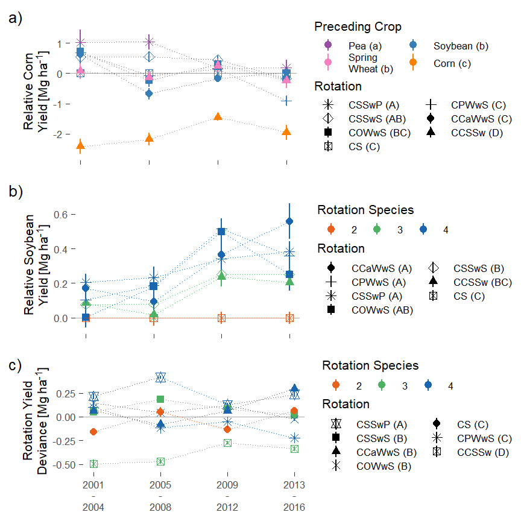

```r
grid.arrange(grobs=list(p2, p3, p4), nrow=3)
```

```r
here('Results', 'Figure 4 - Overyielding.jpg') %>%
  jpeg(width=4, height=4.5, units='in', res=300)
grid.arrange(grobs=list(p2, p3, p4), nrow=3)
dev.off()
```